Boats Segmentation: Drivers Analysis

**Amaka ODOGWU, Evangelos-Pavlo ROUSOS, Dmitry STAKHANOV, Veena VISWANATHAN, and Tavor YISRAEL**

## Business Decisions

In continuing with our analysis of the market segmentation for the boating industry we have created segments around the factors that were previously identified by our team.

## Our Approach

#### Clustering and Segmentation in 8 steps

1. Confirm the data in metric
2. Decide whether to scale or standardize the data
3. Decide which variables to use for clustering
4. Define similarity or dissimilarity measures between observations
5. Visualize Individual Attributes and Pair-wise Distances between the Observations
6. Select the clustering method to use and decide how many clusters to have
7. Profile and interpret the clusters
8. Assess the robustness of our clusters

Let's follow these steps.

#### 2. Decide whether to scale or standardize the data

```r
ProjectData_scaled = apply(ProjectData, 2, function(r) {
    if (sd(r) != 0)
        res = (r - mean(r))/sd(r) else res = 0 * r
    res
})
```

While this is typically a necessary step, one has to always do it with care: some times you may want your analytics findings to be driven mainly by a few attributes that take large values; other times having attributes with different scales may imply something about those attributes. In many such cases one may choose to skip step 2 for some of the raw attributes.

We decide to use the unscaled data for now.

#### Step 3. Decide which variables to use for clustering

For clustering we used key questions for each factor that we identified through our factor analysis:

Q 1.) When buying a boat, I do a lot of shopping around and visit multiple dealers Q 2.) When buying a boat, getting the lowest price is more important than the boat brand Q 4.) I only consider buying a boat from a reputable brand Q 7.) Owning a boat gives me a sense of achievement Q 8.) When buying a boat, functionality is more important than style Q 9.) I see my boat as a status symbol Q 10.) When buying a boat, I rely more on expert opinion than my own (e.g. consumer reports, salespeople) Q 11.) I tend to perform minor boat repairs and maintenance on my own Q 13.) When buying a boat, I tend to buy the latest and greatest Q 19.) Boating allows me to experience nature Q 24.) Boating gives me an outlet to socialize with family and/or friends Q 27.) Boating is the number one thing I do with my spare time Q 29.) Boating is one of many things I do in my spare time

#### Step 4. Define similarity or dissimilarity measures between observations

In our case we explore two distance metrics: the commonly used **Euclidean distance** as well as a simple one we define manually.

Pairwise Distances between the first 5 observations using The Euclidean Distance Metric: Boats

| 1 | 2 | 3 | 4 | 5 |
| --- | --- | --- | --- | --- |
| 0.0 |  |  |  |  |
| 3.5 | 0.0 |  |  |  |
| 3.3 | 2.6 | 0.0 |  |  |
| 3.9 | 3.6 | 3.7 | 0.0 |  |
| 3.9 | 3.0 | 4.5 | 3.5 | 0.0 |

Notice for example that if we use, say, the Manhattan distance metric, these distances change as follows:

Pairwise Distances between the first 5 observations using The Manhattan Distance Metric: Boats

| 1 | 2 | 3 | 4 | 5 |
| --- | --- | --- | --- | --- |
| 0.0 |  |  |  |  |
| 10.0 | 0.0 |  |  |  |
| 9.0 | 7.0 | 0.0 |  |  |
| 9.0 | 9.0 | 10.0 | 0.0 |  |
| 9.0 | 7.0 | 12.0 | 10.0 | 0.0 |

Let's now define our own distance metric, as an example. Let's say that the management team of the company believes that two customers are similar if they do not differ in their ratings of the attitudinal questions by more than 2 points. We can manually assign a distance of 1 for every question for which two customers gave an answer that differs by more than 2 points, and 0 otherwise. It is easy to write this distance function in R:

```r
My_Distance_function <- function(x, y) {
    sum(abs(x - y) > 2)
}
```

Here is how the pairwise distances between the respondents now look like.

Pairwise Distances between the first 5 observations using a simple manually defined Distance Metric: Boats

| 1 | 2 | 3 | 4 | 5 |
| --- | --- | --- | --- | --- |
| 0.0 |  |  |  |  |
| 0.0 | 0.0 |  |  |  |
| 0.0 | 0.0 | 0.0 |  |  |
| 0.0 | 0.0 | 0.0 | 0.0 |  |
| 1.0 | 0.0 | 1.0 | 0.0 | 0.0 |

In general a lot of creative thinking and exploration should be spent in this step, and as always one may need to come back to this step even after finishing the complete segmentation process - multiple times.

#### Step 5. Visualize Individual Attributes and Pair-wise Distances between the Observations

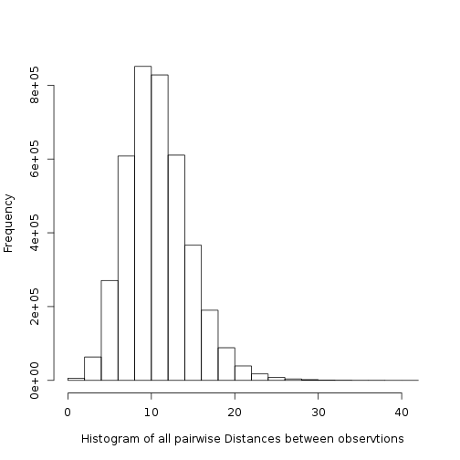

> Visualization is very important for data analytics, as it can provide a first understanding of the data.

For this dataset we felt that the Manhattan distancing method was the most appropriate and yielded the most useable results.

#### Step 6. Select the clustering method to use and decide how many clusters to have

In determining how many clusters to have, we will use two widely used methods: the Kmeans Clustering Method, and the Hierarchical Clustering Method. Both methods are similar in that they require that we have decided how to measure the distance/similarity between our observations. However, they differ in that Kmeans requires us to define how many segments to create, while Hierarchical Clustering does not.

The hierarchical method helps visualize clearly how many clusters there are and how they are grouped, by using the Dendrogram plot, as seen below:

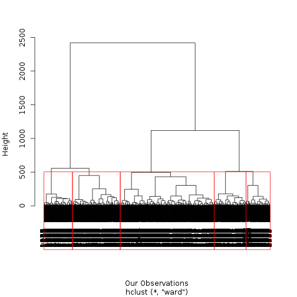

In the Dendrogram, observations are grouped starting from pairs of individual observations which are the closest to each other, and merging smaller groups into larger ones depending on which groups are closest to each other. Eventually all our data is merged into one segment. The heights of the branches of the tree indicate how different the clusters merged at that level of the tree are. Longer lines indicate that the clusters below are very different. As expected, the heights of the tree branches increase as we traverse the tree from the end leaves to the tree root: the method merges data points/groups from the closest ones to the furthest ones.

#### Step 7. Profile and interpret the clusters

Clustering comes out differently depending on the number of clusters used as well as the method of clustering. The goal is to seperate meaningfully different groups based on their responses to questions, but not to seperate into so many groups that each one is essentially the same as the next.

We can also “visualize” the segments using **snake plots** for each cluster. For example, we can plot the means of the profiling variables for each of our clusters to better visualize differences between segments. For better visualization we plot the standardized profiling variables.

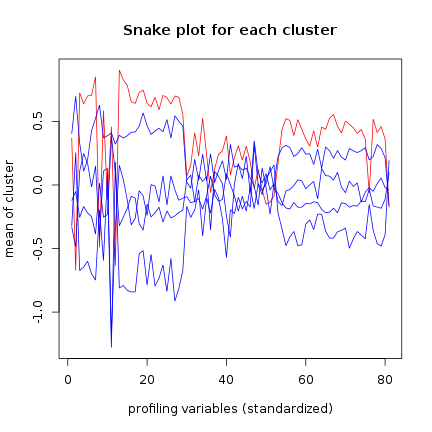

The segments do indeed appear to be quite different in a number of areas. The identified segments responded differently across segments when comparing with each other and similarly when comparing with other members of their own segments.

We can also compare the averages of the profiling variables of each segment relative to the average of the variables across the whole population. This can also help us better understand whether there are indeed clusters in our data (e.g. if all segments are much like the overall population, there may be no segments). For example, we can measure the ratios of the average for each cluster to the average of the population (e.g. avg(cluster)/avg(population)) and explore a matrix as the following one:

|  | Segment 1 | Segment 2 | Segment 3 | Segment 4 | Segment 5 |
| --- | --- | --- | --- | --- | --- |
| Q1_1_When.buying.a.boat..I.do.a.lot.of.shopping.around.and.visit.multiple.dealers | 1.075 | 0.933 | 0.9749 | 1.082 | 0.9341 |
| Q1_2_When.buying.a.boat..getting.the.lowest.price.is.more.important.than.the.boat.brand | 0.764 | 0.8291 | 0.9824 | 1.245 | 1.089 |
| Q1_3_The.brand.of.boat.I.buy.says.a.lot.about.who.I.am | 1.238 | 1.036 | 0.9167 | 1.108 | 0.7794 |
| Q1_4_I.only.consider.buying.a.boat.from.a.reputable.brand | 1.134 | 1.052 | 0.9645 | 1.023 | 0.8639 |
| Q1_5_I.am.willing.to.pay.a.premium.for.a.brand.with.a.reputation.for.high.quality | 1.183 | 1.044 | 0.9427 | 1.052 | 0.8435 |
| Q1_6_Owning.a.boat.is.a.way.of.rewarding.myself.for.my.hard.work | 1.147 | 0.9969 | 0.948 | 1.089 | 0.8542 |
| Q1_7_Owning.a.boat.gives.me.a.sense.of.achievement | 1.208 | 1.037 | 0.9058 | 1.128 | 0.8174 |
| Q1_8_When.buying.a.boat..functionality.is.more.important.than.style | 0.8929 | 0.9126 | 1.003 | 1.137 | 0.9575 |
| Q1_9_I.see.my.boat.as.a.status.symbol | 1.218 | 1.041 | 0.9055 | 1.139 | 0.7787 |
| Q1_10_When.buying.a.boat..I.rely.more.on.expert.opinion.than.my.own..e.g..consumer.reports..salespeople. | 0.9686 | 1.036 | 0.9361 | 1.107 | 1.026 |
| Q1_11_I.tend.to.perform.minor.boat.repairs.and.maintenance.on.my.own | 1.152 | 0.6069 | 1.127 | 1.137 | 0.5749 |
| Q1_12_When.it.comes.to.boating..I.tend.to.prefer.a.basic.boat.with.little.to.no.frills | 0.7751 | 0.8821 | 1.034 | 1.114 | 1.065 |
| Q1_13_When.buying.a.boat..I.tend.to.buy.the.latest.and.greatest | 1.293 | 1.051 | 0.896 | 1.127 | 0.7368 |
| Q1_14_When.buying.accessories.for.my.boat..I.tend.to.buy.the.latest.and.greatest | 1.247 | 1.013 | 0.9246 | 1.111 | 0.7636 |
| Q1_15_I.am.serious.about.the.technology.on.my.boat | 1.193 | 0.9711 | 0.9547 | 1.095 | 0.7963 |
| Q1_16_People.tend.to.come.to.me.for.advice.about.boating | 1.221 | 0.8942 | 0.9701 | 1.14 | 0.7161 |
| Q1_17_I.consider.myself.more.knowledgeable.about.boating.than.the.rest.of.my.boating.peers | 1.203 | 0.9169 | 0.9675 | 1.132 | 0.734 |
| Q1_18_Boating.gives.me.a.feeling.of.adventure | 1.131 | 0.9918 | 0.9453 | 1.084 | 0.9023 |
| Q1_19_Boating.allows.me.to.experience.nature | 1.129 | 0.9853 | 0.9387 | 1.098 | 0.9109 |
| Q1_20_When.not.on.my.boat..I.often.find.myself.doing.boating.related.activities | 1.197 | 0.9262 | 0.9539 | 1.143 | 0.7584 |
| Q1_21_Boating.helps.me.escape.from.everyday.life.and.relax | 1.105 | 1.001 | 0.957 | 1.068 | 0.9066 |
| Q1_22_Boating.helps.me.stay.active | 1.127 | 0.9983 | 0.9594 | 1.078 | 0.8534 |
| Q1_23_Boating.allows.me.to.excel.in.the.sports.that.I.am.passionate.about…e.g..fishing..racing..water.sports. | 1.17 | 0.9613 | 0.9501 | 1.128 | 0.7893 |
| Q1_24_Boating.gives.me.an.outlet.to.socialize.with.family.and.or.friends | 1.13 | 1.013 | 0.9462 | 1.077 | 0.884 |
| Q1_25_Being.in.charge.of.my.boat.is.very.important.to.me | 1.166 | 0.9621 | 0.9509 | 1.124 | 0.7984 |
| Q1_26_Having.a.powerful.boat.is.what.is.most.important.to.me | 1.227 | 1.026 | 0.9076 | 1.132 | 0.7945 |
| Q1_27_Boating.is.the.number.one.thing.I.do.with.my.spare.time | 1.233 | 0.9873 | 0.9191 | 1.181 | 0.6962 |
| Q1_28_Boating.is.my.true.passion.in.life | 1.205 | 0.9645 | 0.9359 | 1.149 | 0.7581 |
| Q1_29_Boating.is.one.of.many.things.I.do.in.my.spare.time | 1.101 | 0.9813 | 0.964 | 1.084 | 0.878 |
| Q2_How.many.powerboats.do.you.currently.own. | 1.06 | 0.9196 | 1.036 | 1.02 | 0.8536 |

[output cut: 51 more lines]

We identified names for the 5 segments and characteristics to describe them:

**Segment 1.) Status Boater**

- The Status Boater cares about the brand of his/her boat, but is more strongly concerned about the technology and power of the boat.
- The Status Boater considers him/herself passionate and knowledgeable about boating and reports boating more than other segments.
- The Status Boater also sees the benefits of boating for other areas of life, including sport, adventure, socializing and relaxation
- The Status boater is the least concerned with price of the identified segments and is the most affluent by a small margin
- The Status Boater does not feel inclinded to purchase this brand of boat in the future, but is extremely likely to recommend it for someone else
- The Status Boater is frequently unemployed

**Segment 2.) Socialite**

- The Socialite tends to be a working woman.
- To him/her a boat is about enteraining and status and he/she identifies less than average with all other uses of boats
- He/she is extremely unlikely to repair a boat on his/her own and does not feel like a boating expert. He/she tends to rely on expert opinion when purchasing a boat, but not as strongly as some other segments
- The brand of boat is very important when selecting a boat, and price is unimportant
- He/she feels moderatly unlikely to purchase or recommend this boat brand in the future

**Segment 3.) Handyman**

- The Handyman focuses on the functionality of the boat over brand or price when purchasing. He/she is not as interested in the power of the boat or the features or style.
- The Handyman is older and more likely to be employed than the average person surveyed
- Despite the fact that the Handyman considers him/herself likely to purchase this brand in the future, he/she does not feel likely to recommend this brand to others.
- Lastly, the reason the Handyman is thus named is because he is likely to repair and maintain his own boat.

**Segment 4.) Young Enthusiast**

- The Young Enthusiast is very concerned about price. Second to price is the power that the boat offers as well as the technology, but having many features is not important.
- He/She enjoys boating and considers it his/her top free time activity and true passion in life and considers him/herself an expert.
- The Young Enthusiast is a solo boater and ses his/her boat for sport.
- The Young Enthusiast is younger than other segments and has slightly less money.
- He/She feels unlikely to purchase this brand in the future but is very willing to recommend it to others

**Segment 5.) Novice**

- The Novice is somewhat apathetic/negative about reasons to purchase a boat, perhaps because the group is not homogenous on this issue.
- The Novice is slightly older, more employed and more often female than the average person surveyed
- He/she relies on expert opinion when purchasing a boat and spend slightly less money on currently owned boats than average
- The Novice is extremly unlikely to repair his/her own boat(s) and does not consider boating a passion.
- The Novice is very unlikely to recommend this brand to others but feels likely to buy this brand in the future.

#### Step 8. Assess the robustness of our clusters

For the class, we will skip this step. However in practice this is a very important step.

## Intepretation, Decisions and Conclusion